# Hwk5-1 Clustering-Solutions

Nithin Mahesh

### Homework 5-1: Clustering with K-means and Model-based Techniques.

##### Examine and prepare the data.

In this activity, you will cluster data from the educational domain. The data file, CourseAttendance.csv, contains data about students in an introductory programming course. This analysis is to explore these data to see if there are any “natural” groupings. If there are groupings, what kind of attendance profiles do we see in the groups, and how do the groups compare in terms of final exam scores.

The data set contains the following variables:

CLASS_LVL : numeric [1,4], year in school GENDER : numeric 1=female, 2=male MAJOR : numeric [1,12], twelve various undergrad majors PREV : numeric [1,3], level of previous programming experience LECATTEND : numeric [1,3], lecture attendence, 1=never, 2= sometimes, 3=always DISCATTEND: numeric [1,3], discussion attendence, 1=never, 2= sometimes, 3=always FINAL : numeric [0,100], final exam score FINALQ : numeric [1,4], final exam score quartile, 1=lowest, 4=highest

Q1(6pts): Write a series of R statements which do the following:

1- Read in the data from the file assigning it to a variable called “data.df”. 2- Change the FINALQ column from numeric to factor, with levels “1st”, “2nd”, “3rd”, “4th”. 3- Create a subset of the data frame for clustering called subset.df which does not include the FINAL and FINALQ columns. 4- Create the variable “exam.labels” and assign to it the FINALQ column in the data frame data.df. Create the variable “exam.scores” and assign to it the FINAL column.

```r
data.df <- read.csv("CourseAttendance.csv")
data.df$FINALQ<-factor(data.df$FINALQ, labels=c("1st","2nd","3rd", "4th"))
subset.df<-subset(data.df[,-7:-8])
exam.labels <- data.df$FINALQ
exam.scores<-data.df$FINAL
```

#### Part 1: Clustering with K-means

You will use the following function to create a plot of within sum of squares.

```r
wssplot <- function(data, nc=15, seed=1234){
               wss <- (nrow(data)-1)*sum(apply(data,2,var))
               for (i in 2:nc){
                    set.seed(seed)
                    wss[i] <- sum(kmeans(data, centers=i)$withinss)}
                plot(1:nc, wss, type="b", xlab="Number of Clusters",
                     ylab="Within groups sum of squares")
           }
```

Q2(2pts): Generate a wss plot on the subset.df data set. State the optimal number of clusters and why the plot supports your conclusion.

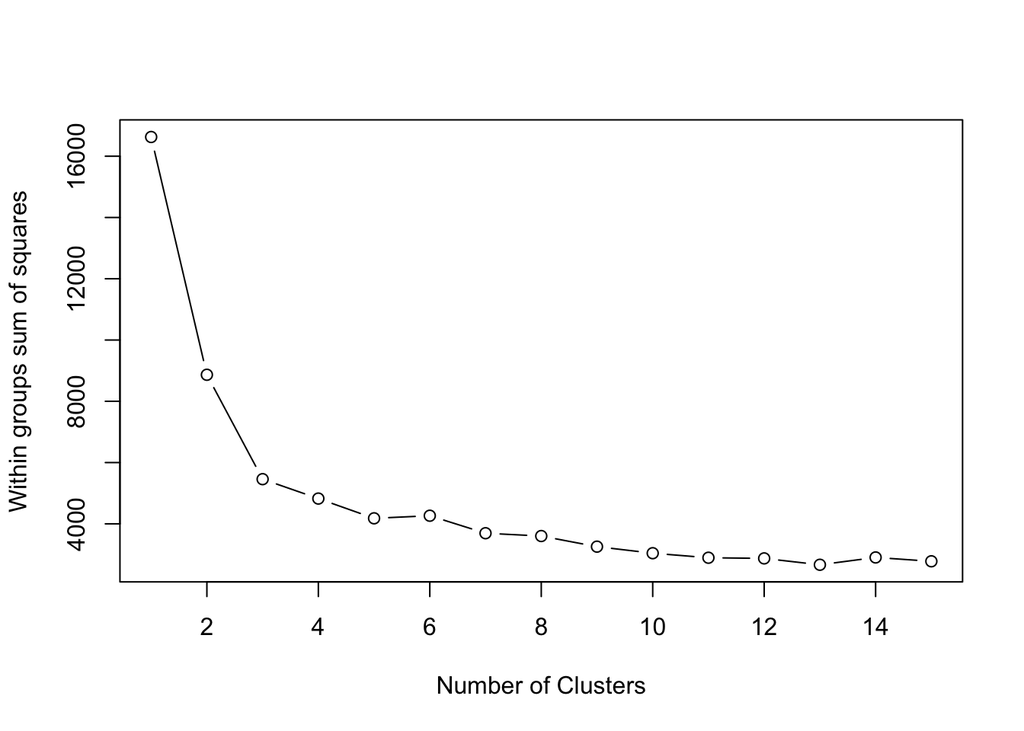

[output not shown]

```r
wssplot(subset.df)
```

Q3(3pts): Use the NbClust function to determine the optimal number of clusters using kmeans. Set the minimum number of clusters at 2, and the max at 10. What does this function return as the optimal number of clusters?

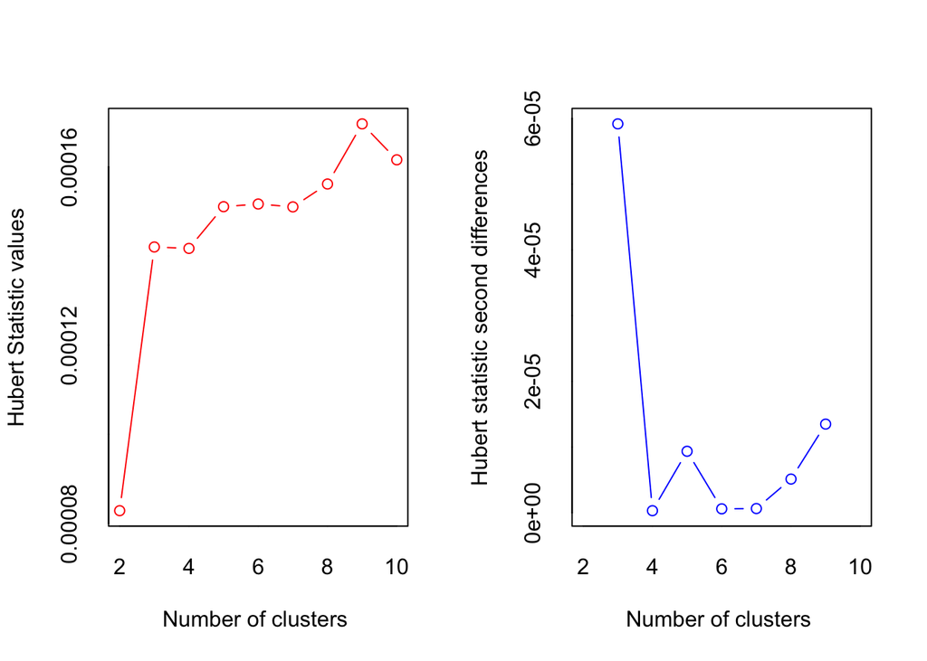

```
## *** : The Hubert index is a graphical method of determining the number of clusters.
##                 In the plot of Hubert index, we seek a significant knee that corresponds to a
##                 significant increase of the value of the measure i.e the significant peak in Hubert
##                 index second differences plot.
##
```

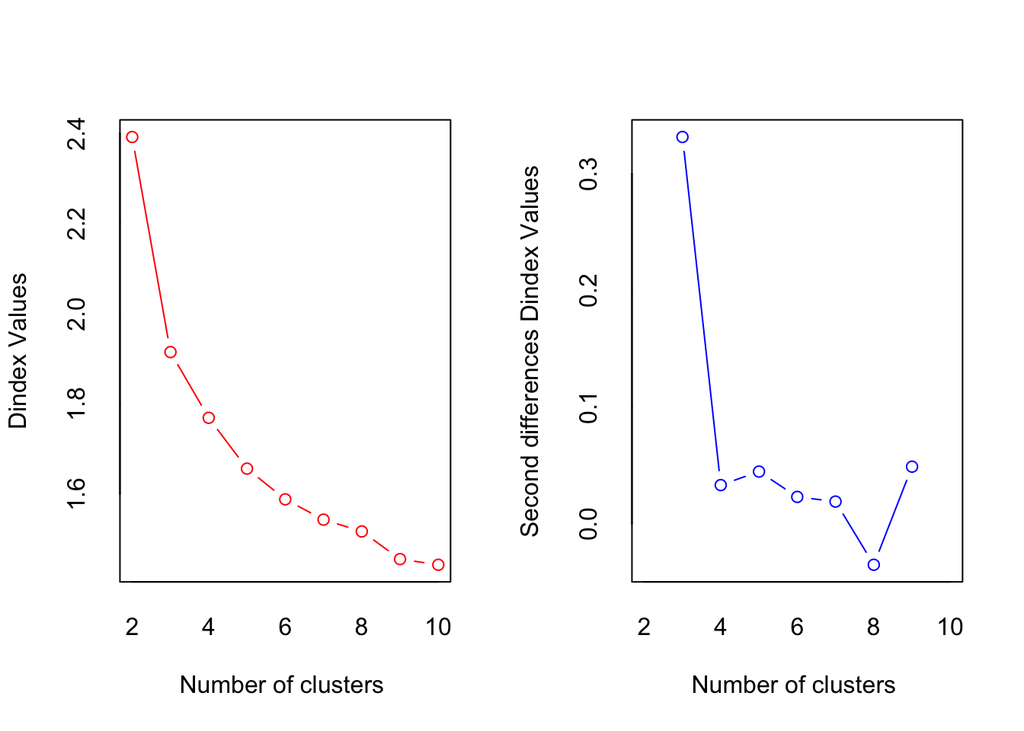

```
## *** : The D index is a graphical method of determining the number of clusters.
##                 In the plot of D index, we seek a significant knee (the significant peak in Dindex
##                 second differences plot) that corresponds to a significant increase of the value of
##                 the measure.
##
## * Among all indices:
## * 5 proposed 2 as the best number of clusters
## * 12 proposed 3 as the best number of clusters
## * 1 proposed 4 as the best number of clusters
## * 1 proposed 5 as the best number of clusters
## * 1 proposed 7 as the best number of clusters
## * 1 proposed 9 as the best number of clusters
## * 2 proposed 10 as the best number of clusters
##
##                    ***** Conclusion *****
##
## * According to the majority rule, the best number of clusters is  3
##
##
```

```r
library(NbClust)
nc <- NbClust(subset.df, min.nc = 2, max.nc=10, method= "kmeans")
```

```r
table(nc$Best.n[1,])
```

```
##
##  0  1  2  3  4  5  7  9 10
##  2  1  5 12  1  1  1  1  2
```

| # The function returns that the best number of clusers is 3. |
| --- |

Q4(2pts): Create a variable “cluster.assignments” and assign to it the vector of cluster assignments made by the NbClust function.

```r
cluster.assignments <- nc$Best.partition
```

#### Evaluating clusters with respect to final exam, attendance

Now examine the clusters created by the NbClust function to see if there are patterns in lecture and discussion attendance, and if the clusters have any relationship to final exam scores.

Q5(8pts): Examine the proportion of lecture attendance for each cluster. Create a contingency table called “cont.table”. Use the LECATTEND column from the data.df data set and the cluster assignments from NbClust in the table. Display the table. Then, display the proportions of lecture attandance across the clusters (the row proportions), and the proportions within each cluster (the column proportions). Run a chi-square test on the table for dependencies. Briefly summarize the proportions across the clusters. Include the results of the chi-square test and what it implies about a relationship between lecture attendance and cluster membership.

```r
cont.table <- table(data.df$LECATTEND, cluster.assignments)
cont.table
```

```
##    cluster.assignments
##       1   2   3
##   1 217  48 151
##   2 211  58 142
##   3 347  93 139
```

```r
prop.table(cont.table, 1)
```

```
##    cluster.assignments
##             1         2         3
##   1 0.5216346 0.1153846 0.3629808
##   2 0.5133820 0.1411192 0.3454988
##   3 0.5993092 0.1606218 0.2400691
```

```r
prop.table(cont.table, 2)
```

```
##    cluster.assignments
##             1         2         3
##   1 0.2800000 0.2412060 0.3495370
##   2 0.2722581 0.2914573 0.3287037
##   3 0.4477419 0.4673367 0.3217593
```

```r
chisq.test(cont.table)
```

```
##
##  Pearson's Chi-squared test
##
## data:  cont.table
## X-squared = 22.325, df = 4, p-value = 0.0001727
```

[output not shown]

Q6(8pts): Examine the proportion of discussion attendance for each cluster. Create a contingency table called “cont.table”. Use the DISCATTEND column from the data.df data set and the cluster assignments from NbClust in the table. Display the table. Then, display the proportions of discussion attendance across the clusters (the row proportions), and the proportions whithin each clauter (the column proportions). Run a chi-square test on the table for dependencies. Briefly summarize the proportions across the clusters. Include the results of the chi-square test and what it implies about a relationship between discussion attendance and cluster membership.

```r
cont.table<- table(data.df$DISCATTEND, cluster.assignments)
cont.table
```

```
##    cluster.assignments
##       1   2   3
##   1 198  48 147
##   2 172  50 100
##   3 405 101 185
```

```r
prop.table(cont.table, 1)
```

```
##    cluster.assignments
##             1         2         3
##   1 0.5038168 0.1221374 0.3740458
##   2 0.5341615 0.1552795 0.3105590
##   3 0.5861071 0.1461650 0.2677279
```

```r
prop.table(cont.table, 2)
```

```
##    cluster.assignments
##             1         2         3
##   1 0.2554839 0.2412060 0.3402778
##   2 0.2219355 0.2512563 0.2314815
##   3 0.5225806 0.5075377 0.4282407
```

```r
chisq.test(cont.table)
```

```
##
##  Pearson's Chi-squared test
##
## data:  cont.table
## X-squared = 14.108, df = 4, p-value = 0.006958
```

[output not shown]

Q7(8pts): Examine the proportion of final exam quartiles for each cluster. Create a contingency table called “cont.table”. Use the exam.labels and cluster assignments in the table. Display the table. Then, display the proportions of each exam quartile across the clusters (the row proportions), and the proportions whithin each clauter (the column proportions). Briefly summarize the proportions of the lowest and highest exam quartiles across the clusters.

```r
cont.table<- table(exam.labels, cluster.assignments)
cont.table
```

```
##            cluster.assignments
## exam.labels   1   2   3
##         1st 173  53 140
##         2nd 199  49 109
##         3rd 209  54  97
##         4th 194  43  86
```

```r
prop.table(cont.table, 1)
```

```
##            cluster.assignments
## exam.labels         1         2         3
##         1st 0.4726776 0.1448087 0.3825137
##         2nd 0.5574230 0.1372549 0.3053221
##         3rd 0.5805556 0.1500000 0.2694444
##         4th 0.6006192 0.1331269 0.2662539
```

```r
prop.table(cont.table, 2)
```

```
##            cluster.assignments
## exam.labels         1         2         3
##         1st 0.2232258 0.2663317 0.3240741
##         2nd 0.2567742 0.2462312 0.2523148
##         3rd 0.2696774 0.2713568 0.2245370
##         4th 0.2503226 0.2160804 0.1990741
```

[output not shown]

Q8(5pts): Graph the average final exam scores for each cluster. Create a variable called “exam.mean”. assign to this variable the mean of the final exam scores for each cluster. Use the vector “exam.scores” you created earlier and the cluster.assignments from NbClust. Use the “tapply” function to apply the “mean” function to the exam scores, grouped by cluster.

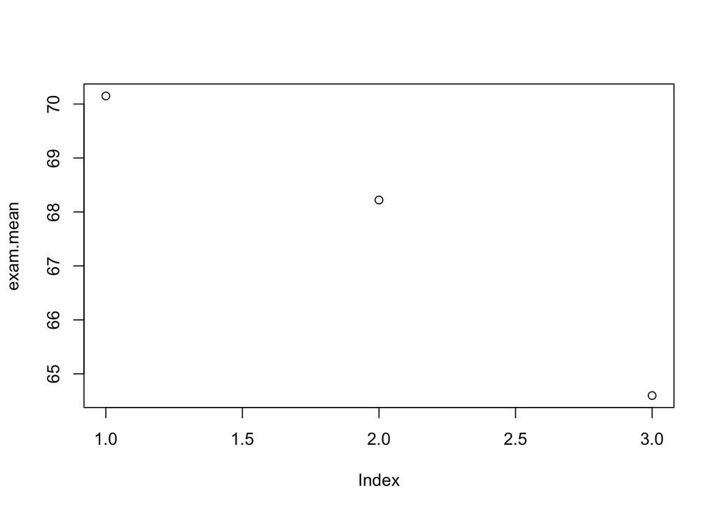

```r
exam.mean<- tapply(exam.scores, cluster.assignments, mean)
plot(exam.mean)
```

Q9(5pts): Use the “barplot” function to plot the means for each cluster (the “exam.mean” vector). Add a title to the plot “Mean Final Exam Scores per Cluster”, a title for the horizontal axis “cluster”, and a title for the vertical axis “mean score”.

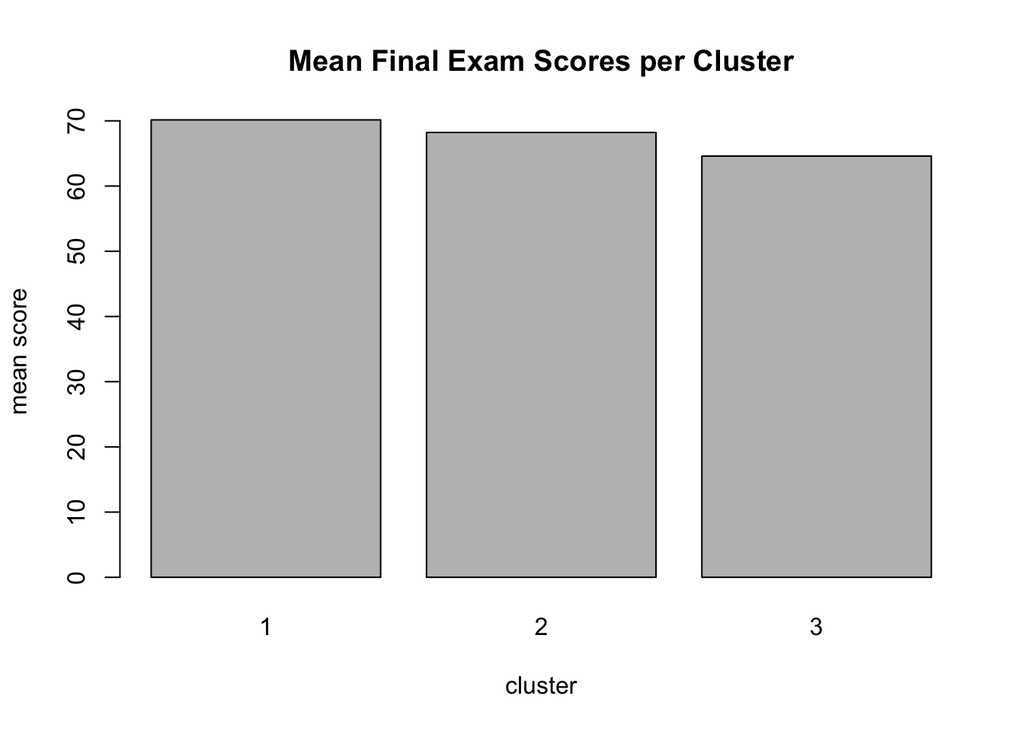

```r
barplot(exam.mean, main = "Mean Final Exam Scores per Cluster", xlab = "cluster", ylab = "mean score")
```

Q10(10pts): Briefy summarize your findings about the clustering and lecture and discussion attendance and final exam scores.

[output not shown]

#### Part 2: Model-based Clustering with the mclust Library

Q11(6pts): Run the Mclust function on the subset.df data set and assign it to a variable called “model.cluster”. Call the “summary” function to display the cluster info. Plot the models and their BIC scores.

```r
library(mclust)
model.cluster<- Mclust(subset.df)
summary(model.cluster)
```

```
## ----------------------------------------------------
## Gaussian finite mixture model fitted by EM algorithm
## ----------------------------------------------------
##
## Mclust EEV (ellipsoidal, equal volume and shape) model with 6 components:
##
##  log.likelihood    n  df       BIC       ICL
##       -8944.042 1406 137 -18881.13 -19344.87
##
## Clustering table:
##   1   2   3   4   5   6
## 124 293 289 160 227 313
```

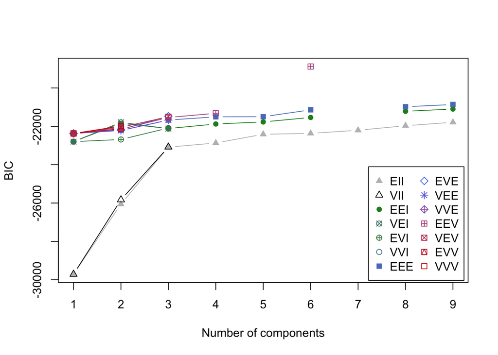

```r
plot(model.cluster, what = "BIC")
```

Q12(6pts): Assign to a variable “cluster.assignments” the cluster assignments from the Mclust object. Then use the “tapply” function to apply the “mean” function to the exam.scores grouping by the cluster assignments. This should display a vector of 6 values which are the mean exam scores for each of the 6 clusters.

```r
cluster.assignments<- model.cluster$classification
tapply(exam.scores, cluster.assignments, mean)
```

```
##        1        2        3        4        5        6
## 68.20968 64.98635 72.67474 65.63125 68.14978 68.29073
```

Q13(5pts): Create a contingency table using the LECATTEND column from the original data set and the cluster assignments from Mclust. Print the table, then display the row and column proportions. Finally, run a chi-square test on the table.

```r
cont.table<- table(data.df$LECATTEND, cluster.assignments)
cont.table
```

```
##    cluster.assignments
##       1   2   3   4   5   6
##   1  64 124  83  60   0  85
##   2  45 114  87  51   4 110
##   3  15  55 119  49 223 118
```

```r
prop.table(cont.table, 1)
```

```
##    cluster.assignments
##              1          2          3          4          5          6
##   1 0.15384615 0.29807692 0.19951923 0.14423077 0.00000000 0.20432692
##   2 0.10948905 0.27737226 0.21167883 0.12408759 0.00973236 0.26763990
##   3 0.02590674 0.09499136 0.20552677 0.08462867 0.38514680 0.20379965
```

```r
prop.table(cont.table, 2)
```

```
##    cluster.assignments
##              1          2          3          4          5          6
##   1 0.51612903 0.42320819 0.28719723 0.37500000 0.00000000 0.27156550
##   2 0.36290323 0.38907850 0.30103806 0.31875000 0.01762115 0.35143770
##   3 0.12096774 0.18771331 0.41176471 0.30625000 0.98237885 0.37699681
```

```r
chisq.test(cont.table)
```

```
##
##  Pearson's Chi-squared test
##
## data:  cont.table
## X-squared = 427.83, df = 10, p-value < 2.2e-16
```

Q14(10pts): Briefly summarize the results from the model-based clustering: What does the BIC plot show about the models and number of clusters? What do the mean exam scores say about the clusters? How does the lecture attandance relate to the mean exam scores in the cluster assignments? What does the chi-square test say about the contingency table?

[output not shown]

Q15(6pts): Call Mclust as in Q11 but specify 3 clusters by passing in the parameter G=3. Print the summary of the Mclust object and plot the BIC score (you will only see one set of models). Repeat Q12 and Q13 with the new clustering.

```r
library(mclust)
model.cluster<- Mclust(subset.df, G = 3)
summary(model.cluster)
```

```
## ----------------------------------------------------
## Gaussian finite mixture model fitted by EM algorithm
## ----------------------------------------------------
##
## Mclust EVE (ellipsoidal, equal volume and orientation) model with 3 components:
##
##  log.likelihood    n df       BIC       ICL
##       -10552.12 1406 51 -21473.91 -21513.51
##
## Clustering table:
##   1   2   3
## 412 213 781
```

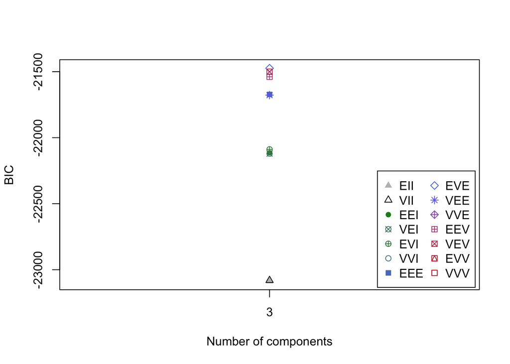

```r
plot(model.cluster, what = "BIC")
```

```r
cluster.assignments<- model.cluster$classification
tapply(exam.scores, cluster.assignments, mean)
```

```
##        1        2        3
## 64.72330 67.93427 70.05378
```

```r
cont.table<- table(data.df$LECATTEND, cluster.assignments)
cont.table
```

```
##    cluster.assignments
##       1   2   3
##   1 145  53 218
##   2 134  62 215
##   3 133  98 348
```

```r
prop.table(cont.table, 1)
```

```
##    cluster.assignments
##             1         2         3
##   1 0.3485577 0.1274038 0.5240385
##   2 0.3260341 0.1508516 0.5231144
##   3 0.2297064 0.1692573 0.6010363
```

```r
prop.table(cont.table, 2)
```

```
##    cluster.assignments
##             1         2         3
##   1 0.3519417 0.2488263 0.2791293
##   2 0.3252427 0.2910798 0.2752881
##   3 0.3228155 0.4600939 0.4455826
```

```r
chisq.test(cont.table)
```

```
##
##  Pearson's Chi-squared test
##
## data:  cont.table
## X-squared = 20.308, df = 4, p-value = 0.0004342
```

Q16(10pts): Briefly summarize the relationship between lecture attendance and final exam scores across the three clusters. Does this agree with the k-means results above?

[output not shown]